# Saúde pública

Achados sobre federalismo fiscal

[figure not shown]

Foto por Hush Naidoo em [Unsplash](https://unsplash.com/photos/pA0uoltkwao)

## A saúde como direito e atribuições do Estado

O direito à saúde foi inserido na Constituição Federal de 1988 no título destinado à ordem social, que tem como objetivo o bem-estar e a justiça social. Nessa perspectiva, a Constituição Federal de 1988, no seu Art. 6º, estabelece como direitos sociais fundamentais a educação, a saúde, o trabalho, o lazer, a segurança, a previdência social, a proteção à maternidade e à infância.

Em seguida, no Art. 196, a Constituição Federal de 1988 reconhece a saúde como direito de todos e dever do Estado, garantido mediante políticas sociais e econômicas que visem à redução do risco de doença e de outros agravos e ao acesso universal e igualitário às ações e serviços para sua promoção, proteção e recuperação.

No sistema federativo fiscal brasileiro a saúde pública é tema peculiar nos debates. Seja pela distribuição das responsabilidades e custeios entre os três níveis da federação, seja por obrigatoriedades de gastos mínimos, ou ainda nas análises referentes às desigualdades regionais que ao final acabam por trazer impactos sobre a oferta e qualidade dos serviços de saúde pública.

## A saúde pública como objeto de estudo do modelo analítico para estudos sobre federalismo

**Autonomia concedida aos entes**

Quando descrevemos os elementos do nosso modelo, evidenciamos que ocorre de fato a divisão das responsabilidades de gastos entre os três níveis federativos em relação à saúde pública. É preciso, no entanto, que a descentraçização das ações de saúde pública faz com que os atores que são de fato agentes da implementação da política públicas sejam de fato os Estados e Municípios. A figura abaixo mostra como o gasto de saúde pública do governo central brasileiro se distribui em classificações econômicas

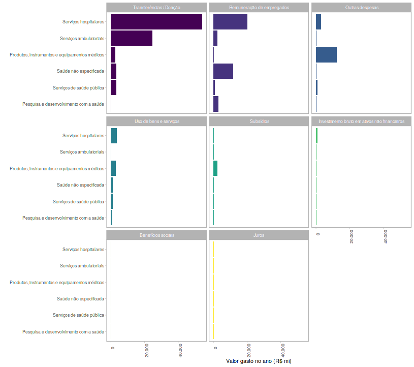

Classificações econômicas dos gastos com saúde do Governo Central: 2019 [Dashboard Cofog](https://painel-cofog.tesouro.gov.br/dashboard_cofog.Rmd#section-especificacao-das-despesas---classificacao-economica)

Veja na figura que os gastos estão majoritariamente concentrados em transferência para os outros entes. Isso implica que os serviços hospitalares e serviços ambulatoriais destacados na figura são na prática oferecidos principalmente pelos estados e municípios tendo como fonte importante de recursos valores oriundos da União.

Podemos ter uma ideia de como as despesas têm evoluído ao longo dos anos nos entes dos três níveis federativos brasileiro. Começando pela união.

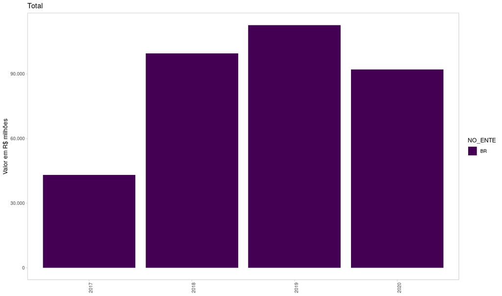

Gastos com saúde do Governo Central: 2017-2020 [Meu SICONFI](https://meusiconfi.tesouro.gov.br/Interface_rsiconfi.rmd)

Observa-se aqui um considerável aumento de 2017 para 2018 seguido de um leve aumento para 2019 e uma queda em 2020.

Veja agora abaixo a evolução e o gasto total com saúde pelos estados brasileiros entre 2015 e 2020.

[figure not shown]

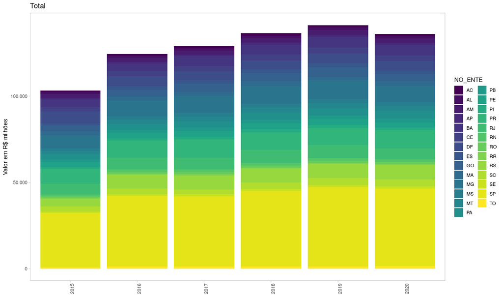

Gastos com saúde dos Estados: 2015-2020 [Meu SICONFI](https://meusiconfi.tesouro.gov.br/Interface_rsiconfi.rmd)

Quando se trata de municípios, pode ser interenssante identificar como se distribui a proporção da desepsa em saúde comparada com o total de despesas. Além disso, é importante entender os grupos que se assemelham quando se utiliza essa variável como parâmetro. Veja a figura abaixo.

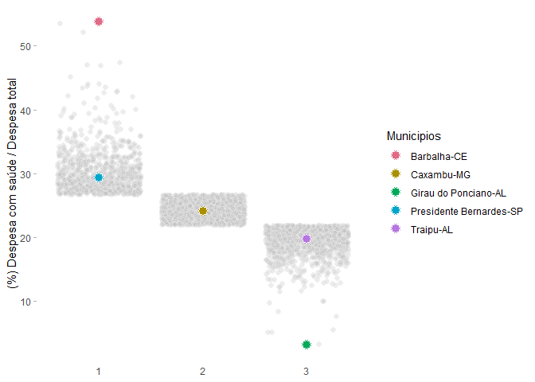

Usando recursos estatísticos conseguimos identificar 3 grupos de municípios a partir da relação:despesa com saúde / despesas totais considerando no caso a soma dos valores para toda série temporal. No gráfico estão assinalados os municípios que ocupam os pontos de máxima e de mínima e outros três que ocupam o centro de cada um dos grupos.

As posições centrais de cada grupo variam entre 19,70% e 29,30%. Esse pontos centrais são interessantes de serem destacados já que dentro de cada grupo, principalmente para o grupo intermediário, a relação analisada não será muito diferente dos valores centrais. As exceções para essa distribuição são raras, com destaque para os extremos: Barbalha (53,79% da despesa total) e Girau do Ponciano (3,1% da despesa total).

Os municípios destacados no gráfico podem ser analisados com mais detalhes para entender o que pode estar mais influenciando a relação: se a despesa com saúde ou se a despesa total. É interessante então comparar os diversos valores dessas duas variáveis, bem como o ranking que essas cidades ocupam tanto em despesas totais como em despesas com saúde. A tabela abaixo faz a apresentação de alguns dados que podem permitir essa primeira análise para esses municípios paradigmáticos.

| IBGE | Município | UF | Desespa com saúde | Ranking saúde | Total de despesa | Ranking Despesa Total | Relação (%) | Grupo |
| --- | --- | --- | --- | --- | --- | --- | --- | --- |
| 2301901 | Barbalha | CE | 123.845.569 | 186 | 230.233.221 | 403 | 53,79 | 1 |
| 3541208 | Presidente Bernardes | SP | 12.965.524 | 1.380 | 44.246.265 | 1.692 | 29,30 | 1 |
| 3115508 | Caxambu | MG | 12.274.003 | 1.451 | 51.010.214 | 1.490 | 24,06 | 2 |
| 2709202 | Traipu | AL | 11.850.735 | 1.495 | 60.060.236 | 1.303 | 19,73 | 3 |
| 2702900 | Girau do Ponciano | AL | 441.673 | 3.445 | 14.330.258 | 3.286 | 3,08 | 3 |

Como se vê Barbalha se destaca dos demais municípios por ocupar uma posição relativamente de destaque nos rankings de despesa com saúde e de despesa total, considerando o número de municípios analisados. Então pode-se descartar que a elevada relação entre despesa com saúde e despesa total não é derivada de baixas despesas totais comparativamente ao restante dos municípos. Observa-se de fato que a posição do ranking na despesa com saúde é quase a metade da posição da despesa total. Os demais municípios apresentam posições de ranking próximas entre as duas variáveis que entram no cálculo da relação focada nesta análise. Assim como Barbalha, Presidente Bernardes e Caxambu exibem uma posição de ranking de saúde menor do que a de despesa total e o inverso ocorre nas outras duas cidades.

**Mecanismos de colaboração**

No Brasil, a Constituição Federal prevê diversos mecanismos de cooperação, como o estabelecimento de órgãos regionais de desenvolvimento, os repasses obrigatórios de receitas tributárias (federais para Estados-Membros e Municípios; e estaduais para Municípios), a concessão de subsídios e incentivos fiscais a outros entes. Entra no rol também as transferências verticais voluntárias para os fins mais diversos, a exemplo dos fundos de desenvolvimento regional

**Vinculação orçamentária** Determinações a priori de destinações orçamentárias por todos os entes, a exemplo do que ocorre com a educação e saúde

**Equalização Fiscal**

O desequilíbrio entre receitas e despesas de entes descentralizados é chamado de **desequilíbrio vertical**, resultante de consideráveis disparidades entre as fontes de receitas e obrigações de despesas funcionais entre os governos de uma Federação.

O **desequilíbrio horizontal** ocorre quando há disparidades de receitas e despesas analisadas entre unidades federativas do mesmo nível (Estados versus Estados; Municípios versus Municípios). O problema do desequilíbrio horizontal resulta das diferenças entre as áreas econômicas do país, da distribuição da renda e riqueza.

**Municipalização**

É importante discutir que a maior quantidade de municípios, assim como a criação de novas cidades sem condições de se autossustentar, contribui para a ampliação dos problemas de disparidades socioeconômicas (a ser discutido na próxima seção), dado que a criação de Municípios pode onerar os cofres públicos, trazendo diferentes gastos sem receita oriunda de arrecadação própria, sendo, portanto, necessária a utilização de receitas advindas de transferências, que poderiam ser empregadas para outros fins, por exemplo, investimentos em saúde, educação, segurança pública, transportes etc.

**Recursos administrativos**

No que diz respeito à falta de recursos administrativos, para que um processo de descentralização fiscal ocorra, é necessário que se tenha capacidade operacional para realizar tal tarefa, com todas as suas implicações. Como exemplo temos: a disponibilidade de instituições locais que deem sustentação à ação governamental subnacional; a disponibilidade de funcionários qualificados e capazes de planejar tanto o processo arrecadatório, quanto as políticas públicas. Nesse caso, serão despendidos recursos e, ainda, a capacidade de disponibilizar mecanismos de controle dos gastos que garantam sua transparência

**Função distributiva da economia**

A função distributiva da economia do setor público refere-se à distribuição de renda. Bens econômicos são produzidos, e os governos exercem algum papel em modificar a distribuição de bens determinada no mercado entre os membros de uma dada sociedade. Em vista disso, a função distributiva do governo está voltada para a necessidade dele em intervir na economia para tentar corrigir a desigualdade existente na distribuição da renda que, normalmente, não é igualitária.

**Função alocativa da economia** A função alocativa do governo está associada ao fornecimento de bens e serviços não oferecidos adequadamente pelo sistema de mercado. Essa função tem o objetivo de alocar os recursos, quando não for possível pelas condições de mercado, tendo em vista a determinação de preços de bens e serviços de forma a assegurar uma maior eficiência na utilização dos recursos disponíveis na economia. Por exemplo, a construção de estradas, que contribui para a expansão econômica de determinada região. Nos casos em que se verifiquem falhas no mercado competitivo, como as externalidades, assimetria de informação ou bens públicos, seria necessária a intervenção do Estado para promover uma alocação de recursos mais satisfatória

A escassez de recursos deve ser alocada de maneira eficiente sob um sistema de descentralização fiscal, e os governos subnacionais podem estar em uma melhor posição, pois entendem como maximizar os benefícios do uso de recursos em sua localidade.

Em resumo, se a dimensão local de bens públicos é ignorada, a provisão de tais bens no mesmo nível entre todas as regiões irá comprometer a eficiência quando as preferências por bens públicos locais diferirem por regiões, jurisdições ou níveis de governo. Como resultado, os governos subnacionais possuem o potencial de exercer melhor a função de alocação eficiente dos recursos. Nesta função do governo, a intenção em mobilizar recursos de maneira regional é reconhecida de tal modo que as preferências das famílias heterogêneas possam ser mais bem atendidas.

**Exportação de tributos**

Cada comunidade (estado ou município) pode criar tributos que incidam sobre não-residentes. No Brasil, o Imposto sobre Circulação de Mercadoria e Serviços (ICMS) é um exemplo dessa situação. Uma pessoa que compra, em Sergipe, um carro produzido em São Paulo estará pagando parte do imposto embutido no preço do carro ao Estado de São Paulo, ainda que nunca tenha ido àquele Estado ou usado os serviços públicos por ele ofertados. Em um processo de decisão descentralizada, haveria uma tendência a se utilizar excessivamente esse tipo de tributo, para que os bens públicos locais fossem financiados por pessoas de outras comunidades.

**Externalidades positivas**

Seriam ignorados os benefícios que os bens públicos proporcionam aos não residentes. A preservação ambiental ou a prevenção de doenças em uma jurisdição, por exemplo, também geram benefícios às comunidades vizinhas. Decidindo isoladamente a alocação de recursos públicos, um governo local deixa de computar os benefícios aos não residentes. A consequência seria uma oferta insuficiente daqueles bens.

**Comportamento free rider**

Um governo local pode deixar de prover (ou prover em menor quantidade) um serviço público, uma vez que já goza dos benefícios proporcionados pela jurisdição vizinha. Também nesse caso o Brasil apresenta um caso típico. Municípios situados próximos a grandes cidades, em vez de construir seus próprios hospitais públicos, preferem oferecer ambulâncias para levar seus doentes para o hospital do Município vizinho. Com isso, economizam seus recursos à custa da sobrecarga do sistema hospitalar que é pago pelos contribuintes de outro Município.

Cada comunidade procura se livrar de atividades econômicas ou serviços públicos que, embora gerem benefícios à sociedade, também produzem efeitos negativos locais. Esse fenômeno é conhecido na literatura como not in my backyard (“no meu quintal, não”) e consiste na sobretaxação ou proibição (taxação infinita) de instalação na comunidade de atividades como usinas nucleares, depósito de lixo ou penitenciárias (ARVATE; BIDERMAN, 2004, p. 428). Por exemplo, os prefeitos costumam protestar quando o governo estadual anuncia que pretende construir uma penitenciária no seu município.

**Regressividade tributária e do perfil dos gastos**

A mobilidade dos indivíduos tende a ser diretamente relacionada à riqueza (pessoas mais ricas têm maiores incentivos e melhores meios de se mudar para fugir de impostos), então haveria uma tendência dos governos locais a estabelecer estruturas tributárias e perfil de gastos públicos regressivos. Com isso, cada comunidade estaria espantando pobres e atraindo ricos para ali residirem.

**Guerra fiscal**

É possível pensar que a competição entre os entes por recursos públicos e privados seja saudável, pois conduzirá a uma alocação dos recursos mais eficiente, ou seja, para aquele que apresentar maior atração a tal alocação. O problema nesta ideia é que o ente que receber o investimento será beneficiado, pois terá sua economia dinamizada e expandirá sua base arrecadatória, ao passo que a arrecadação agregada da sociedade será reduzida. As comunidades poderiam tentar manipular tributos, aquisição de insumos para bens públicos e oferta de bens públicos com vistas a gerar aumento de renda local à custa de outras comunidades. Ou seja, abre-se a possibilidade de uma guerra fiscal entre as comunidades. Esse é um problema típico da federação brasileira, em que os estados oferecem incentivos fiscais a grandes empresas para que elas se instalem em seus territórios. O resultado é a concessão de incentivos cada vez maiores, exigindo que outros contribuintes, não beneficiários dos incentivos, sejam excessivamente tributados, para manter o financiamento do setor público.